# anovafunctions

```r
library(anovafunctions)
library(ggplot2)
```

# Using anova

This vignette is intended for users who use anova within their package code, currently the anova package is compatible with one-way anova for numerical and categorical factors and two-way anova for either two categorical factors or one categorical and one numeric factor. Anova utilizes other packages including flextable and ggplot2 to generate anova results and appropriate plots for those results. As well as interpreting specific result values such as p-values, r-squared, and confidence intervals and prediction intervals.

## Background

The development of this package was inspired by questions that commonly appeared in a Biostatistics Methods course the developer was taking at the time of its creation. A few frequently encountered questions in this course are as follows… 1. Test if the effect is statistically significant at level 0.05( Is the p-value less that 0.05?) 2. Obtain the 95% confidence interval and prediction interval for the dependent variable when the independent variable(s) =x and interpret your result. 3. Fit a straight-line regression for the model. Each of these questions and more are addressed in anova. The functions ‘report_overall_pval_anova’ and ‘report_pvals_anova’ address challenge one the first finds the overall p value for one way anova, and the second finds the p-value for each factor and interaction if it exists. For problem two, ‘interpret_one_anova_intervals’ and ‘interpret_anova_regression_intervals’ calculate and print interpretations of both intervals for one-way and two-way anova respectively. Problem 3 is addressed by ‘plot_anova_regression_ci_pi’. Many challenges of anova analysis are also addressed in this package. In the early stages of the development of anova the main focus was placed on generating linear regression plots and creating tables with values for confidence bands and prediction bands. However, as development progressed the package expanded to include one-way and two-way anova analysis. This occurred because the developer became more comfortable with their knowledge of anova analysis and was able to determine more beneficial ways to utilized r programming.

## Using functions developed for One-Way ANOVA

### One-Way Anova when x-variable is numerical

First let’s go through an example where both x and y variables are numeric, using the nhanes data set from the aplore3 package. For this example the default significance level (95%)/alpha=0.05 will be used to examine the effect of total cholesterol(tchol) on systolic blood pressure(sysbp).

```r
oneway_anova_flextable(sysbp~tchol, aplore3::nhanes)
```

```
#> $anova_table
#> a flextable object.
#> col_keys: `Term`, `Df`, `Sum Sq`, `Mean Sq`, `F value`, `Pr(>F)`
#> header has 1 row(s)
#> body has 2 row(s)
#> original dataset sample:
#> 'data.frame':    2 obs. of  6 variables:
#>  $ Term   : chr  "tchol      " "Residuals  "
#>  $ Df     : num  1 5586
#>  $ Sum Sq : num  46881 1806080
#>  $ Mean Sq: num  46881 323
#>  $ F value: num  145 NA
#>  $ Pr(>F) : chr  "<0.0001" NA
#>
#> $summary_table
#> a flextable object.
#> col_keys: `R.Square`, `Coeff.Var`, `Root.MSE`, `Response.Mean`
#> header has 1 row(s)
#> body has 1 row(s)
#> original dataset sample:
#> 'data.frame':    1 obs. of  4 variables:
#>  $ R.Square     : num 0.0253
#>  $ Coeff.Var    : num 14.6
#>  $ Root.MSE     : num 18
#>  $ Response.Mean: num 123
#>
#> $parameter_estimates
#> a flextable object.
#> col_keys: `Term`, `Estimate`, `Std. Error`, `t value`, `Pr(>|t|)`
#> header has 1 row(s)
#> body has 2 row(s)
#> original dataset sample:
#> 'data.frame':    2 obs. of  5 variables:
#>  $ Term      : chr  "(Intercept)" "tchol"
#>  $ Estimate  : num  109.4545 0.0701
#>  $ Std. Error: num  1.14391 0.00582
#>  $ t value   : num  95.7 12
#>  $ Pr(>|t|)  : chr  "<0.0001" "<0.0001"
```

```r
report_overall_pval_anova(sysbp~tchol, aplore3::nhanes)
```

```
#> ANOVA Report
#> Model:  sysbp ~ tchol
#> P-value:  <0.0001
#> Alpha:  0.05
#> Conclusion: The effect is SIGNIFICANT at the 0.05 level.
```

```r
report_oneway_anova_r2(sysbp~tchol, aplore3::nhanes)
```

```
#> One-Way ANOVA R-squared
#> ------------------------
#> Response variable: sysbp
#> Grouping variable: tchol
#>
#> R-squared = 0.0253
#>
#> Interpretation:
#> -Approximately 2.5% of the variation in sysbp is explained by differences between the levels of tchol.
#> - The remaining 97.5% of the variation is due to variability within groups.
```

```r
interpret_one_anova_intervals(sysbp~tchol, aplore3::nhanes, x_value=170)
```

```
#> Prediction for tchol = 170
#> --------------------------------------
#> Estimated mean sysbp = 121.3777
#>
#> 95% Confidence Interval (mean response):
#>   CI = 120.8433 to 121.912
#> Interpretation: We are 95% confident that the TRUE MEAN sysbp for x = 170 lies within this interval.
#>
#> 95% Prediction Interval (individual response):
#>   PI = 86.1235 to 156.6318
#> Interpretation: We are 95% confident that a SINGLE FUTURE observation of sysbp at x = 170 will fall within this interval.
```

Please note the confidence interval is very small for this example.

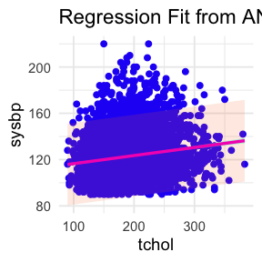

```r
plot_anova_regression_ci_pi(sysbp~tchol, aplore3::nhanes)
```

### One-Way Anova when x-variable is categorical

```r
oneway_anova_flextable(bwt~ptl,aplore3::lowbwt, alpha=0.10)
```

```
#> $anova_table
#> a flextable object.
#> col_keys: `Term`, `Df`, `Sum Sq`, `Mean Sq`, `F value`, `Pr(>F)`
#> header has 1 row(s)
#> body has 2 row(s)
#> original dataset sample:
#> 'data.frame':    2 obs. of  6 variables:
#>  $ Term   : chr  "ptl        " "Residuals  "
#>  $ Df     : num  2 186
#>  $ Sum Sq : num  5586362 94330691
#>  $ Mean Sq: num  2793181 507154
#>  $ F value: num  5.51 NA
#>  $ Pr(>F) : chr  "0.0047" NA
#>
#> $summary_table
#> a flextable object.
#> col_keys: `R.Square`, `Coeff.Var`, `Root.MSE`, `Response.Mean`
#> header has 1 row(s)
#> body has 1 row(s)
#> original dataset sample:
#> 'data.frame':    1 obs. of  4 variables:
#>  $ R.Square     : num 0.0559
#>  $ Coeff.Var    : num 24.2
#>  $ Root.MSE     : num 712
#>  $ Response.Mean: num 2945
#>
#> $parameter_estimates
#> a flextable object.
#> col_keys: `Term`, `Estimate`, `Std. Error`, `t value`, `Pr(>|t|)`
#> header has 1 row(s)
#> body has 3 row(s)
#> original dataset sample:
#> 'data.frame':    3 obs. of  5 variables:
#>  $ Term      : chr  "(Intercept)" "ptlOne" "ptlTwo, etc."
#>  $ Estimate  : num  3014 -517 -102
#>  $ Std. Error: num  56.5 156 296.2
#>  $ t value   : num  53.359 -3.317 -0.344
#>  $ Pr(>|t|)  : chr  "<0.0001" "0.0011" "0.7316"
```

```r
report_overall_pval_anova(bwt~ptl,aplore3::lowbwt, alpha=0.10)
```

```
#> ANOVA Report
#> Model:  bwt ~ ptl
#> P-value:  0.004745
#> Alpha:  0.1
#> Conclusion: The effect is SIGNIFICANT at the 0.1 level.
```

```r
report_oneway_anova_r2(bwt~ptl,aplore3::lowbwt)
```

```
#> One-Way ANOVA R-squared
#> ------------------------
#> Response variable: bwt
#> Grouping variable: ptl
#>
#> R-squared = 0.0559
#>
#> Interpretation:
#> -Approximately 5.6% of the variation in bwt is explained by differences between the levels of ptl.
#> - The remaining 94.4% of the variation is due to variability within groups.
```

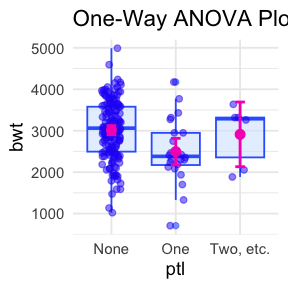

```r
boxplot_oneway_anova_ci(bwt~ptl,aplore3::lowbwt)
```

## Using Functions Developed for Two-way ANOVA

### Two-way ANOVA when Both Factors are Categorical

In this example, both factors are categorical and the default significance level (95%)/alpha=0.05 will be used to examine the effect of neuropsyhiatric disturbance (neuro) and emotional disturbance (emot) with interaction on behavioral symptoms score(behav) using the aps dataset from the aplore3 package. When working with interaction, for all functions besides ‘twoway_anova_plots’ using the fulling syntax (response~factor1*factor2, data).

```r
twoway_anova_flextable(behav~neuro*emot,aplore3::aps)
```

```
#> $anova_table
#> a flextable object.
#> col_keys: `Term`, `Df`, `Sum Sq`, `Mean Sq`, `F value`, `Pr(>F)`
#> header has 1 row(s)
#> body has 4 row(s)
#> original dataset sample:
#> 'data.frame':    4 obs. of  6 variables:
#>  $ Term   : chr  "neuro      " "emot       " "neuro:emot " "Residuals  "
#>  $ Df     : num  3 1 3 500
#>  $ Sum Sq : num  17.22 9.58 7.77 1995.86
#>  $ Mean Sq: num  5.74 9.58 2.59 3.99
#>  $ F value: num  1.438 2.4 0.649 NA
#>  $ Pr(>F) : chr  "0.2308" "0.1220" "0.5842" NA
#>
#> $summary_table
#> a flextable object.
#> col_keys: `R.Square`, `Adj.R.Square`, `Model.SS`, `Error.SS`, `Total.SS`, `Root.MSE`, `Coeff.Var....`, `Response.Mean`
#> header has 1 row(s)
#> body has 1 row(s)
#> original dataset sample:
#> 'data.frame':    1 obs. of  8 variables:
#>  $ R.Square     : num 1
#>  $ Adj.R.Square : num 1
#>  $ Model.SS     : num 2030
#>  $ Error.SS     : num 1996
#>  $ Total.SS     : num 2030
#>  $ Root.MSE     : num 2
#>  $ Coeff.Var....: num 34
#>  $ Response.Mean: num 5.88
#>
#> $parameter_estimates
#> a flextable object.
#> col_keys: `Term`, `Estimate`, `Std. Error`, `t value`, `Pr(>|t|)`
#> header has 1 row(s)
#> body has 8 row(s)
#> original dataset sample:
#> 'data.frame':    8 obs. of  5 variables:
#>  $ Term      : chr  "(Intercept)" "neuroMild" "neuroModerate" "neuroSevere" ...
#>  $ Estimate  : num  5.928 0.388 -0.241 -0.311 -0.52 ...
#>  $ Std. Error: num  0.12 0.284 0.514 0.363 0.266 ...
#>  $ t value   : num  49.562 1.366 -0.469 -0.856 -1.958 ...
#>  $ Pr(>|t|)  : chr  "<0.0001" "0.1726" "0.6394" "0.3924" ...
```

```r
report_pvals_anova(behav~neuro*emot,aplore3::aps)
```

```
#>
#> ANOVA Report
#> Model: behav ~ neuro * emot
#>
#> Factor 1 p-value:        0.2308  -->  NOT SIGNIFICANT
#> Factor 2 p-value:        0.122  -->  NOT SIGNIFICANT
#> Interaction p-value:     0.5842  -->  NOT SIGNIFICANT
#>
#> Alpha = 0.05
```

```r
report_twoway_anova_r2(behav~neuro*emot,aplore3::aps)
```

```
#> ANOVA R-squared Report
#> ------------------------
#> Response variable: behav
#> Model terms: neuro, emot, neuro:emot
#>
#> R-squared = 0.5043
#> Adjusted R-squared = 0.0016
#>
#> Interpretation:
#> 50.4% of the variation in behav is explained by the model terms: neuro, emot, neuro:emot.
```

The syntax of ‘twoway_anova_plots’ is different from the previous functions to call this function use this format (data, response, factor 1, factor 2)

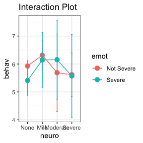

```
#>
#> $main_effect_factor1
#> `geom_line()`: Each group consists of only one observation.
#> ℹ Do you need to adjust the group aesthetic?
```

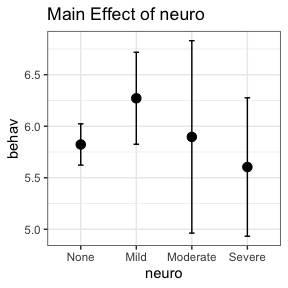

```
#>
#> $main_effect_factor2
#> `geom_line()`: Each group consists of only one observation.
#> ℹ Do you need to adjust the group aesthetic?
```

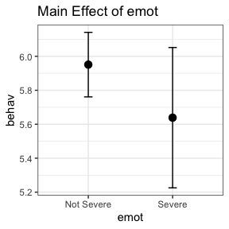

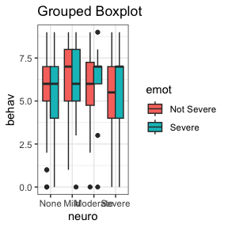

```r
twoway_anova_plots(aplore3::aps, behav, neuro, emot )
```

### Two-way ANOVA when One Factor is Numerical and the Other is Categorical

```r
twoway_anova_flextable(bmi~tchol+vigrecexr, aplore3::nhanes, alpha=0.10)
```

```
#> $anova_table
#> a flextable object.
#> col_keys: `Term`, `Df`, `Sum Sq`, `Mean Sq`, `F value`, `Pr(>F)`
#> header has 1 row(s)
#> body has 3 row(s)
#> original dataset sample:
#> 'data.frame':    3 obs. of  6 variables:
#>  $ Term   : chr  "tchol      " "vigrecexr  " "Residuals  "
#>  $ Df     : num  1 1 6049
#>  $ Sum Sq : num  1154 5233 244865
#>  $ Mean Sq: num  1153.7 5232.7 40.5
#>  $ F value: num  28.5 129.3 NA
#>  $ Pr(>F) : chr  "<0.0001" "<0.0001" NA
#>
#> $summary_table
#> a flextable object.
#> col_keys: `R.Square`, `Adj.R.Square`, `Model.SS`, `Error.SS`, `Total.SS`, `Root.MSE`, `Coeff.Var....`, `Response.Mean`
#> header has 1 row(s)
#> body has 1 row(s)
#> original dataset sample:
#> 'data.frame':    1 obs. of  8 variables:
#>  $ R.Square     : num 1
#>  $ Adj.R.Square : num 1
#>  $ Model.SS     : num 251251
#>  $ Error.SS     : num 244865
#>  $ Total.SS     : num 251251
#>  $ Root.MSE     : num 6.36
#>  $ Coeff.Var....: num 22.2
#>  $ Response.Mean: num 28.6
#>
#> $parameter_estimates
#> a flextable object.
#> col_keys: `Term`, `Estimate`, `Std. Error`, `t value`, `Pr(>|t|)`
#> header has 1 row(s)
#> body has 3 row(s)
#> original dataset sample:
#> 'data.frame':    3 obs. of  5 variables:
#>  $ Term      : chr  "(Intercept)" "tchol" "vigrecexrNo"
#>  $ Estimate  : num  25.25693 0.00839 2.2651
#>  $ Std. Error: num  0.40614 0.00198 0.19923
#>  $ t value   : num  62.19 4.23 11.37
#>  $ Pr(>|t|)  : chr  "<0.0001" "<0.0001" "<0.0001"
```

```r
report_pvals_anova(bmi~tchol+vigrecexr, aplore3::nhanes, alpha=0.10)
```

```
#>
#> ANOVA Report
#> Model: bmi ~ tchol + vigrecexr
#>
#> Factor 1 p-value:        <0.0001  -->  SIGNIFICANT
#> Factor 2 p-value:        <0.0001  -->  SIGNIFICANT
#> Interaction p-value:     NA  -->  NA
#>
#> Alpha = 0.1
```

```r
report_twoway_anova_r2(bmi~tchol+vigrecexr, aplore3::nhanes)
```

```
#> ANOVA R-squared Report
#> ------------------------
#> Response variable: bmi
#> Model terms: tchol, vigrecexr
#>
#> R-squared = 0.5064
#> Adjusted R-squared = 0.0127
#>
#> Interpretation:
#> 50.6% of the variation in bmi is explained by the model terms: tchol, vigrecexr.
```

The syntax of ‘interpret_anova_regression_intervals’ is different from the previous functions, to call this function use this format (formula, data, newdata) The newdata frame can be created with in the function shown here or outside the function.

```r
interpret_anova_regression_intervals(bmi~tchol+vigrecexr, aplore3::nhanes, newdata <- data.frame(
  tchol = 220,
  vigrecexr = factor("Yes", levels = levels(aplore3::nhanes$vigrecexr))
))
```

```
#> Predictions for newdata:
#>   tchol vigrecexr
#> 1   220       Yes
#>
#> ------------------------------
#> Estimated mean = 27.1021
#>
#> 95% Confidence Interval:
#>   CI = 26.7317 to 27.4725
#> Interpretation: We are 95% confident that the TRUE MEAN response lies in this interval.
#>
#> 95% Prediction Interval:
#>   PI = 14.624 to 39.5802
#> Interpretation: A SINGLE FUTURE observation is expected to fall in this interval.
```

Here is the same example showing the newdata frame created outside the function.

```r
newdata <- data.frame(
  tchol = 220,
  vigrecexr = factor("Yes", levels = levels(aplore3::nhanes$vigrecexr))
)

interpret_anova_regression_intervals(bmi~tchol+vigrecexr, aplore3::nhanes, newdata)
```

```
#> Predictions for newdata:
#>   tchol vigrecexr
#> 1   220       Yes
#>
#> ------------------------------
#> Estimated mean = 27.1021
#>
#> 95% Confidence Interval:
#>   CI = 26.7317 to 27.4725
#> Interpretation: We are 95% confident that the TRUE MEAN response lies in this interval.
#>
#> 95% Prediction Interval:
#>   PI = 14.624 to 39.5802
#> Interpretation: A SINGLE FUTURE observation is expected to fall in this interval.
```

## Shiny App

This package also comes with a shiny application that allows you to upload a dataset, run One-way ANOVA and generate appropriate plots for visualization. Run the following function to open the shiny application

```r
run_oneway_app()
```

## Future Improvements

One improvement that can be made to this package would be adding the option for users to change how variable names appear on plots and tables. This can be accomplished by adding extra parameters to the function for variable labels and then including within the function if/else statement that checks to see if those parameters are specified, if yes the function will print the specified label, if not the function will default to the variable names from the data set. User options can also be expanded to include the option to change the colors used on plots. This could be done by adding extra parameters (for example pointcolor)to the function and then within the function assigning the color to the parameter(pointcolor) instead of an actual color(black). Also, an additional shiny application can be made to use with two-way ANOVA. The UI from the one-way ANOVA could be used with minimal changes, but the server would need to be changed to work with two-way ANOVA.